# Mice Protein Expression Analysis

Yilan Li

```r
library(tidyverse)
data <- read.csv("data.csv")
```

## Data Description

This dataset comes from the **UC Machine Learning Repository** [Mice Protein Expression](https://archive.ics.uci.edu/dataset/342/mice+protein+expression). It consists of expression levels of 77 proteins modifications that produced signals in the nuclear fraction of the cortex. The dataset includes measurements from **38 control mice** and **34 trisomic mice** (Down syndrome).

```r
data
```

| MouseID | DYRK1A_N | ITSN1_N | BDNF_N | NR1_N | NR2A_N | pAKT_N | pBRAF_N | pCAMKII_N | pCREB_N | pELK_N | pERK_N | pJNK_N | PKCA_N | pMEK_N | pNR1_N | pNR2A_N | pNR2B_N | pPKCAB_N | pRSK_N | AKT_N | BRAF_N | CAMKII_N | CREB_N | ELK_N | ERK_N | GSK3B_N | JNK_N | MEK_N | TRKA_N | … |
| --- | --- | --- | --- | --- | --- | --- | --- | --- | --- | --- | --- | --- | --- | --- | --- | --- | --- | --- | --- | --- | --- | --- | --- | --- | --- | --- | --- | --- | --- | --- |
| 309_1 | 0.5036439 | 0.7471932 | 0.4301753 | 2.816329 | 5.990152 | 0.21883002 | 0.17756549 | 2.373744 | 0.2322238 | 1.7509356 | 0.6879062 | 0.30638172 | 0.4026984 | 0.29692732 | 1.0220603 | 0.6056726 | 1.8776837 | 2.3087453 | 0.44159937 | 0.85936577 | 0.4162891 | 0.3696080 | 0.1789443 | 1.8663581 | 3.685247 | 1.5372267 | 0.26452630 | 0.3196770 | 0.8138665 | … |
| 309_2 | 0.5146171 | 0.6890635 | 0.4117703 | 2.789514 | 5.685038 | 0.21163615 | 0.17281702 | 2.292150 | 0.2269721 | 1.5963769 | 0.6950062 | 0.29905109 | 0.3859868 | 0.28131889 | 0.9566759 | 0.5875587 | 1.7257740 | 2.0430365 | 0.44522189 | 0.83465925 | 0.4003642 | 0.3561775 | 0.1736797 | 1.7610467 | 3.485287 | 1.5092495 | 0.25572702 | 0.3044187 | 0.7805042 | … |
| 309_3 | 0.5091831 | 0.7302468 | 0.4183088 | 2.687201 | 5.622059 | 0.20901090 | 0.17572221 | 2.283337 | 0.2302468 | 1.5613162 | 0.6773484 | 0.29127607 | 0.3810025 | 0.28171035 | 1.0036350 | 0.6024488 | 1.7318730 | 2.0179835 | 0.46766788 | 0.81432944 | 0.3998469 | 0.3680888 | 0.1739047 | 1.7655443 | 3.571456 | 1.5012435 | 0.25961355 | 0.3117467 | 0.7851540 | … |
| 309_4 | 0.4421067 | 0.6170762 | 0.3586263 | 2.466947 | 4.979503 | 0.22288584 | 0.17646260 | 2.152301 | 0.2070042 | 1.5950862 | 0.5832768 | 0.29672866 | 0.3770870 | 0.31383195 | 0.8753903 | 0.5202932 | 1.5668522 | 2.1327542 | 0.47767069 | 0.72770463 | 0.3856387 | 0.3629700 | 0.1794489 | 1.2862766 | 2.970137 | 1.4197095 | 0.25953577 | 0.2792181 | 0.7344917 | … |
| 309_5 | 0.4349402 | 0.6174298 | 0.3588022 | 2.365785 | 4.718679 | 0.21310595 | 0.17362696 | 2.134014 | 0.1921579 | 1.5042299 | 0.5509601 | 0.28696119 | 0.3635021 | 0.27796428 | 0.8649120 | 0.5079898 | 1.4800591 | 2.0136968 | 0.48341614 | 0.68779374 | 0.3675305 | 0.3553109 | 0.1748355 | 1.3246945 | 2.896334 | 1.3598765 | 0.25070498 | 0.2736672 | 0.7026991 | … |
| 309_6 | 0.4475064 | 0.6281758 | 0.3673881 | 2.385939 | 4.807635 | 0.21857777 | 0.17623337 | 2.141282 | 0.1951875 | 1.4423982 | 0.5663396 | 0.28982390 | 0.3638930 | 0.26683694 | 0.8591209 | 0.5213066 | 1.5382444 | 1.9682753 | 0.49589999 | 0.67240221 | 0.3694045 | 0.3571717 | 0.1797285 | 1.2274499 | 2.956983 | 1.4479097 | 0.25084017 | 0.2840436 | 0.7043958 | … |
| 309_7 | 0.4280327 | 0.5736958 | 0.3427090 | 2.334224 | 4.473130 | 0.22517285 | 0.18400377 | 2.012414 | 0.1957888 | 1.6120365 | 0.5098994 | 0.29965431 | 0.3711502 | 0.27765556 | 0.8442803 | 0.4853865 | 1.4948146 | 2.0125707 | 0.49748586 | 0.64613451 | 0.3959774 | 0.3595223 | 0.1860465 | 1.1077938 | 2.599623 | 1.3642363 | 0.26147077 | 0.2762414 | 0.6931175 | … |
| 309_8 | 0.4169226 | 0.5640356 | 0.3277027 | 2.260135 | 4.268735 | 0.21483415 | 0.17966831 | 2.007985 | 0.1898034 | 1.4246007 | 0.5010749 | 0.28301597 | 0.3588759 | 0.25644963 | 0.8186425 | 0.4785012 | 1.4093980 | 1.8570332 | 0.48955774 | 0.62807125 | 0.3607187 | 0.3607187 | 0.1718366 | 1.0773956 | 2.550215 | 1.3166462 | 0.25061425 | 0.2653563 | 0.6765971 | … |
| 309_9 | 0.3863109 | 0.5384281 | 0.3177204 | 2.125725 | 4.063950 | 0.20722158 | 0.16777842 | 1.861514 | 0.1806845 | 1.2618910 | 0.4766531 | 0.26696636 | 0.3370070 | 0.24260441 | 0.7482599 | 0.4589617 | 1.3417923 | 1.8220708 | 0.46447216 | 0.60063805 | 0.3265661 | 0.3288863 | 0.1703886 | 1.0088457 | 2.434600 | 1.2520302 | 0.23042343 | 0.2526102 | 0.6355858 | … |
| 309_10 | 0.3808274 | 0.4992936 | 0.3624622 | 2.096266 | 3.598587 | 0.22764884 | 0.18809284 | 1.717861 | 0.1880928 | 1.4143290 | 0.4554995 | 0.32411705 | 0.3683148 | 0.28375378 | 0.7434914 | 0.4441978 | 1.3553986 | 1.7832492 | 0.49303734 | 0.57053481 | 0.3354188 | 0.3921292 | 0.1983855 | 0.9061554 | 2.169929 | 1.2482341 | 0.25771947 | 0.3015136 | 0.6367306 | … |

[output cut: 1070 more lines]

### What are the columns represent

**Mouse ID**: Unique identifier for each mouse, **15 measurements** were taken for each protein per mouse.

**Expression Levels**: The dataset contains values for the expression levels of **77 proteins**.

**Genotype**: The genotype of each mouse, either **control (c)** or **trisomy (t)**.

**Treatment Type**: The treatment administered to the mouse, either **memantine (m)** or **saline (s)**.

**Behavior**: Describes the behavioral context of each mouse, either **context-shock (CS)** or **shock-context (SC)**.

### Classes

The mice are classified into eight groups based on features such as **genotype**, **behavior**, and **treatment**. The genotypes can either be **control** or **trisomic**. In terms of behavior, some mice have been stimulated to learn (context-shock), while others have not (shock-context). Additionally, in order to assess the effect of the drug **memantine** on the ability to learn in trisomic mice, some mice were injected with the drug, and others were injected with saline as control.

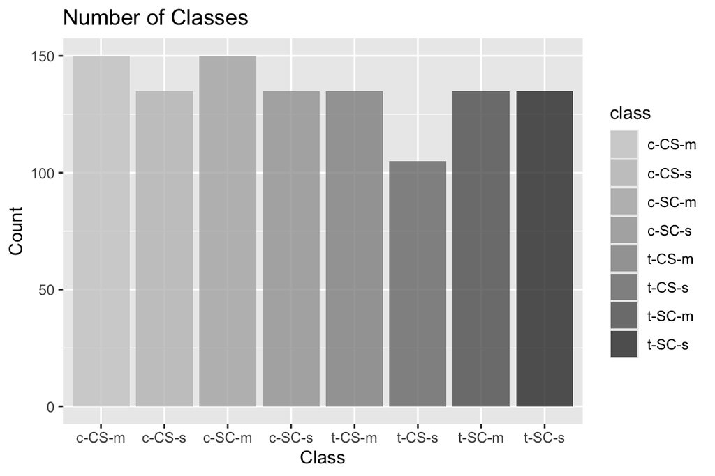

```r
ggplot(data, aes(class)) +
  geom_bar(aes(fill = class), alpha = 0.8) +
  scale_fill_grey (start = 0.8, end = 0.2) +
  labs(title = "Number of Classes", y = "Count", x="Class")
```

- **c-CS-s**: Control mice, stimulated to learn, injected with saline (9 mice)
- **c-CS-m**: Control mice, stimulated to learn, injected with memantine (10 mice)
- **c-SC-s**: Control mice, not stimulated to learn, injected with saline (9 mice)
- **c-SC-m**: Control mice, not stimulated to learn, injected with memantine (10 mice)
- **t-CS-s**: Trisomic mice, stimulated to learn, injected with saline (7 mice)
- **t-CS-m**: Trisomic mice, stimulated to learn, injected with memantine (9 mice)
- **t-SC-s**: Trisomic mice, not stimulated to learn, injected with saline (9 mice)
- **t-SC-m**: Trisomic mice, not stimulated to learn, injected with memantine (9 mice)

## Data Cleaning and handle missing values

The dataset contains some missing values. In this case, we will handle the missing values by replacing them with the mean of the corresponding protein group.

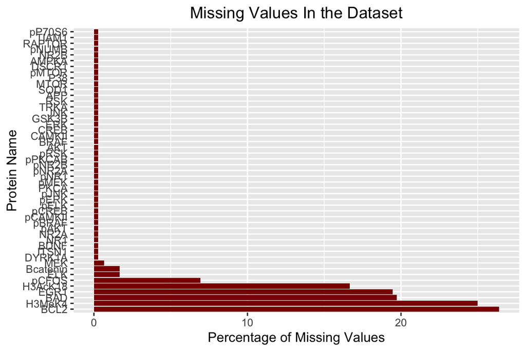

```r
missing_values <- data %>%
  setNames(gsub("_N", "", names(.))) %>%
  summarise(across(everything(), ~ sum(is.na(.)), .names = "{.col}")) %>%
  pivot_longer(everything(), names_to = "key", values_to = "missing") %>%
  mutate(
    total = nrow(data),
    pct = (missing / total) * 100,
    isna = missing > 0
  ) %>%
  filter(isna) %>%
  arrange(desc(pct))

percentage.plot <- missing_values %>%
  ggplot(aes(x = reorder(key, pct), y = pct)) +
  geom_bar(stat = 'identity', fill = 'darkred', alpha = 1) +
  scale_x_discrete(limits = missing_values$key) +
  coord_flip() +
  labs(title = "Missing Values In the Dataset", x = 'Protein Name', y = "Percentage of Missing Values") +
  theme(plot.title = element_text(hjust = 0.5)) +
  guides(fill = "none")
percentage.plot
```